# Customer Churn Analysis in Telecom Industry

# Bivariate Analysis Summary

### Key Business Implications

1. **Contract Strategy**: Converting month-to-month to annual contracts could reduce churn by 75%
2. **Payment Optimization**: Migrating electronic check users could reduce churn by 64%
3. **Tenure Focus**: First-year customers need targeted retention efforts
4. **Pricing Strategy**: $65 appears as psychological price threshold

### Statistical Significance

All identified relationships show: - Clear visual separation in distributions - Large effect sizes in means and medians - Consistent patterns across multiple visualizations - Business-meaningful magnitude differences

# Multivariate Plots Section

## 9. Tenure vs Monthly Charges by Churn Status

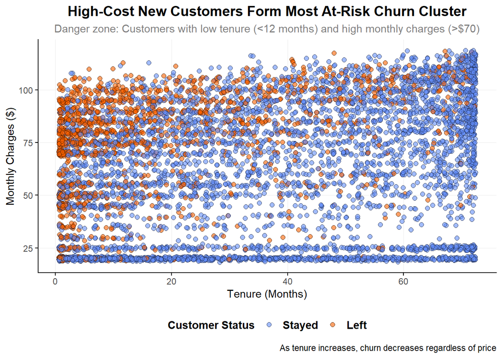

```r
plot_9 <- ggplot(cleaned_data, aes(x = tenure, y = monthly_charges, fill = factor(churn))) +
  geom_jitter(alpha = 0.6, size = 2, shape = 21, color = "black") +
  labs(
    title = "High-Cost New Customers Form Most At-Risk Churn Cluster",
    subtitle = "Danger zone: Customers with low tenure (<12 months) and high monthly charges (>$70)",
    x = "Tenure (Months)",
    y = "Monthly Charges ($)",
    caption = "As tenure increases, churn decreases regardless of price"
  ) +
  scale_fill_manual(name = "Customer Status",
                    values = c("0" = "#648FFF", "1" = "#FE6100"),
                    labels = c("Stayed", "Left")) +
  theme_custom

plot_9
```

**Critical Insight:** The **highest risk segment** combines: - **Low tenure** (< 12 months) - **High monthly charges** (> $70)

This represents **price-sensitive new customers** who may feel they’re not getting value for money.

## 10. Tenure-Based Churn Rate by Contract Type

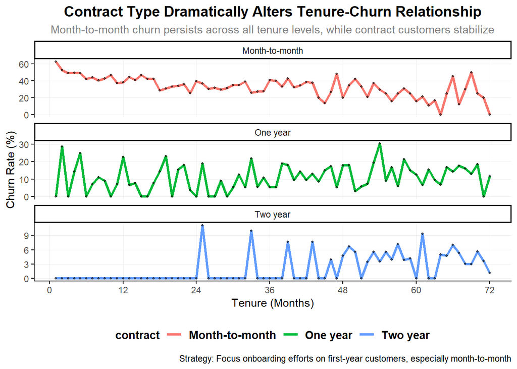

```r
plot_data3 <- cleaned_data |>
  group_by(tenure, contract) |>
  summarise(
    churned_sum = sum(churn),
    total = n(),
    rate = churned_sum/total * 100
  ) |>
  ungroup()

plot_10 <- ggplot(plot_data3, aes(x = tenure, y = rate)) +
  geom_line(linewidth = 1.2, aes(color = contract)) +
  geom_point(size = 0.75, alpha = 0.6) +
  facet_wrap(~ contract, ncol = 1, scales = "free_y") +
  labs(
    title = "Contract Type Dramatically Alters Tenure-Churn Relationship",
    subtitle = "Month-to-month churn persists across all tenure levels, while contract customers stabilize",
    x = "Tenure (Months)",
    y = "Churn Rate (%)",
    caption = "Strategy: Focus onboarding efforts on first-year customers, especially month-to-month"
  ) +
  scale_x_continuous(breaks = seq(0, max(plot_data3$tenure), by = 12)) +
  theme_custom

plot_10
```

**Strategic Implication:** The **first 12 months** are critical for establishing retention, especially for month-to-month customers.

# Multivariate Analysis Summary

### High-Risk Customer Segments Identified

Based on multivariate analysis, the **most vulnerable segments** are:

### Protective Factors Identified